# Comparative Analysis of Economic Growth and Energy Mix

```r
library(readr)

# URL of the CSV file on GitHub
url <- "https://raw.githubusercontent.com/rfordatascience/tidytuesday/master/data/2023/2023-06-06/owid-energy.csv"

# Reading the CSV file into a dataframe
energy_data <- read_csv(url)
```

**Question:** How does recent economic development impact a region’s energy mix (renewables vs. non-renewables)?

**Introduction:**

The dataset from *Our World in Data*’s Energy Data Explorer provides an extensive overview of global energy consumption, delineating the mix between renewable and non-renewable energy sources. In exploring the interplay between economic growth and energy mix over the last two decades, we will examine key columns such as `country` and `year` for geographical and temporal context, `population` and `gdp` for economic scaling, and various forms of energy production:

- `solar_electricity` - Electricity generation from solar, measured in terawatt-hours
- `wind_electricity` - Electricity generation from wind, measured in terawatt-hours
- `hydro_electricity` - Electricity generation from hydropower, measured in terawatt-hours
- `other_renewable_electricity` - Primary energy consumption from other renewables, measured in terawatt-hours
- `coal_electricity` - Electricity generation from coal, measured in terawatt-hours
- `oil_electricity` - Electricity generation from oil, measured in terawatt-hours
- `gas_electricity` - Electricity generation from gas, measured in terawatt-hours
- `nuclear_electricity` - Electricity generation from nuclear, measured in terawatt-hours

For this analysis, the focus is on unpacking the influence of economic growth on the composition of regional energy mixes over the past two decades. This analysis will entail comparing renewable and non-renewable energy sources, examining trends, and identifying shifts in this period.

**Approach:**

This study analyzes how economic development affects regional energy mixes. We compare energy consumption (renewable and non-renewable) across regions and correlate it with economic indicators (GDP, population). Grouped cluster plots will visually represent changes in consumption types over time (2001, 2009, 2017). Additionally, scatter plots will explore the link between GDP and renewable energy use, with data points sized by population for insights into energy density. These visualizations aim to reveal regional trends and potential outliers for further investigation.

**Analysis:**

```r
#head function, just to peep
head(energy_data)
```

```
## # A tibble: 6 × 129
##   country      year iso_code population   gdp biofuel_cons_change_pct
##   <chr>       <dbl> <chr>         <dbl> <dbl>                   <dbl>
## 1 Afghanistan  1900 AFG         4832414    NA                      NA
## 2 Afghanistan  1901 AFG         4879685    NA                      NA
## 3 Afghanistan  1902 AFG         4935122    NA                      NA
## 4 Afghanistan  1903 AFG         4998861    NA                      NA
## 5 Afghanistan  1904 AFG         5063419    NA                      NA
## 6 Afghanistan  1905 AFG         5128808    NA                      NA
## # ℹ 123 more variables: biofuel_cons_change_twh <dbl>,
## #   biofuel_cons_per_capita <dbl>, biofuel_consumption <dbl>,
## #   biofuel_elec_per_capita <dbl>, biofuel_electricity <dbl>,
## #   biofuel_share_elec <dbl>, biofuel_share_energy <dbl>,
## #   carbon_intensity_elec <dbl>, coal_cons_change_pct <dbl>,
## #   coal_cons_change_twh <dbl>, coal_cons_per_capita <dbl>,
## #   coal_consumption <dbl>, coal_elec_per_capita <dbl>, …
```

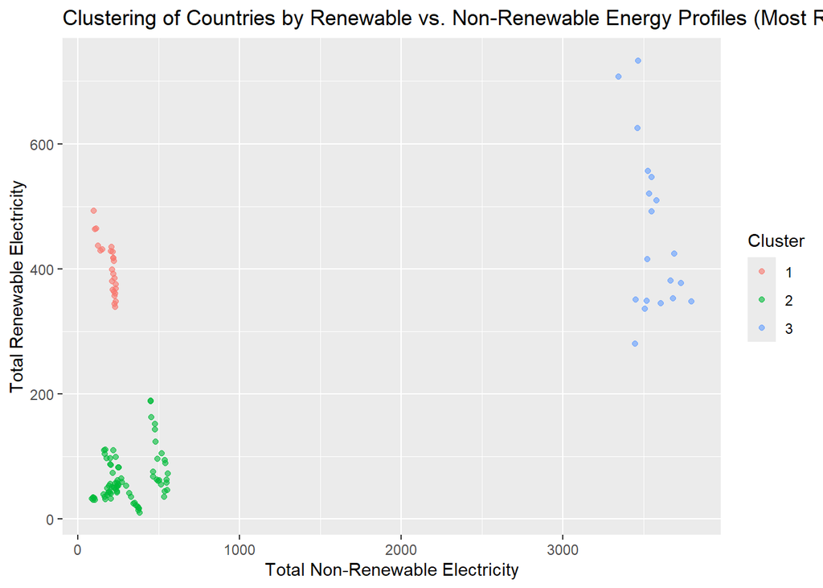

```r
library(ggplot2)
library(dplyr)

# Calculate total renewable and non-renewable electricity
energy_data <- energy_data %>%
  mutate(total_renewable = solar_electricity + wind_electricity + hydro_electricity + other_renewable_electricity,
         total_non_renewable = coal_electricity + oil_electricity + gas_electricity + nuclear_electricity,
         total_electricity = total_renewable + total_non_renewable) %>%
  na.omit()

# Normalize data
scaled_data <- scale(energy_data[, c("total_renewable", "total_non_renewable")])

# K-means Clustering
set.seed(123)  # For reproducibility
clusters <- kmeans(scaled_data, centers = 3)
energy_data$cluster <- as.factor(clusters$cluster)

# Scatter plot for clustering
ggplot(energy_data, aes(x = total_non_renewable, y = total_renewable, color = cluster)) +
  geom_point(alpha = 0.6) +
  labs(x = "Total Non-Renewable Electricity", y = "Total Renewable Electricity", color = "Cluster",
       title = "Clustering of Countries by Renewable vs. Non-Renewable Energy Profiles (Most Recent Year)")
```

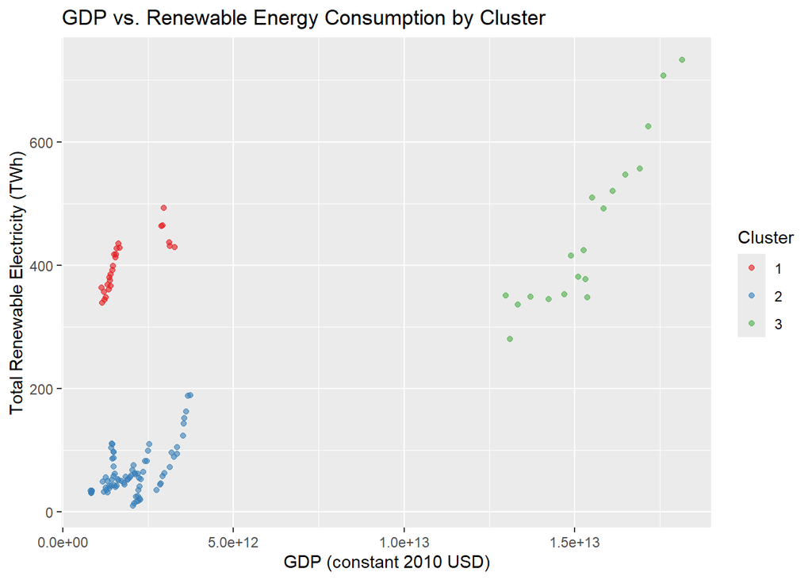

```r
energy_data <- energy_data %>%
  filter(!is.na(gdp), !is.na(total_renewable)) %>%
  mutate(cluster = as.factor(cluster))

# Scatter plot of GDP vs. Total Renewable Electricity
ggplot(energy_data, aes(x = gdp, y = total_renewable, color = cluster)) +
  geom_point(alpha = 0.6) +
  scale_color_brewer(palette = "Set1") +
  labs(x = "GDP (constant 2010 USD)", y = "Total Renewable Electricity (TWh)", color = "Cluster",
       title = "GDP vs. Renewable Energy Consumption by Cluster")
```

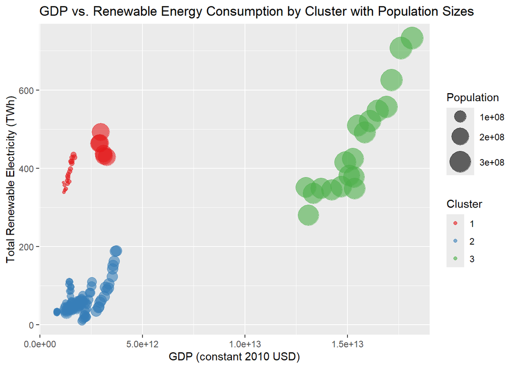

```r
# Scatter plot of GDP vs. Total Renewable Electricity but accounting for population size
ggplot(energy_data, aes(x = gdp, y = total_renewable, color = cluster, size = population)) +
  geom_point(alpha = 0.6) +
  scale_size(range = c(1, 10)) +
  scale_color_brewer(palette = "Set1") +
  labs(x = "GDP (constant 2010 USD)",
       y = "Total Renewable Electricity (TWh)",
       color = "Cluster",
       size = "Population",
       title = "GDP vs. Renewable Energy Consumption by Cluster with Population Sizes")
```

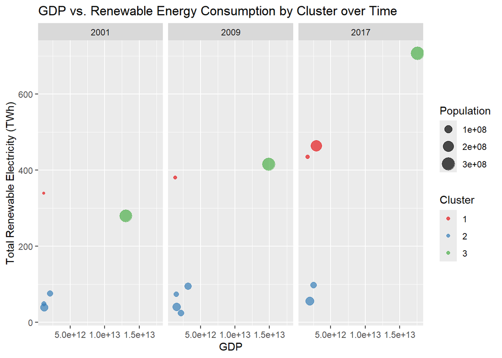

```r
time_series_data <- energy_data %>%
  filter(year %in% c(2001, 2009, 2017)) %>%
  mutate(year = as.factor(year)) # Convert year to a factor for faceting

# Faceted time series plot
time_series_plot <- ggplot(time_series_data, aes(x = gdp, y = total_renewable,
                                                 color = cluster, size = population)) +
  geom_point(alpha = 0.7) +
  facet_wrap(~ year) +
  scale_color_brewer(palette = "Set1") +
  labs(x = "GDP",
       y = "Total Renewable Electricity (TWh)",
       color = "Cluster",
       size = "Population",
       title = "GDP vs. Renewable Energy Consumption by Cluster over Time")

print(time_series_plot)
```

**Discussion:**

- **Regional Variations:** The visualizations highlight significant differences in how countries utilize energy. Cluster plots based on renewable and non-renewable consumption reveal distinct groups. One cluster leans heavily on non-renewables, another prioritizes renewables, and a smaller group might be outliers with exceptionally high renewable use.
- **Economic Influence and Population Dynamics:** Now that these regional variations have been identified, the scatter plots then suggest a positive correlation between GDP and renewable energy consumption. Wealthier nations likely have more resources to invest in renewable infrastructure, lending to this trend. Moreover, clusters may emerge grouping countries with similar economic development and energy profiles. Population size plays a role, as larger countries generally have higher GDPs. However, the spread of data points indicates factors beyond population, such as development status, energy policies, and resource availability, also influence energy consumption patterns.
- **Insights and Future Implications:** Ultimately, these observed trends likely stem from a variety of factors such as:
  - *Economic development*: Wealthier nations often have more resources to invest in renewable energy infrastructure, leading to the positive correlation between GDP and renewable energy consumption.
  - *Government policies*: Government policies and incentives can largely impact the adoption of renewable energy, which could explain the clusters that emerged.
  - *Technological advancements*: Advances in technology can potentially make renewable energy more accessible and affordable, influencing consumption patterns positively.
  - *Resource availability*: Countries rich in renewable resources such as hydro, solar, or wind potential are more likely to utilize these and thus appear higher in renewable energy consumption charts.